# Example 3 - defined *in vitro* differentiation of mESCs

```python
> python ../../dpre.py -pt "mouse" -se "ivd_expression.tsv" -c "ivd ESCs (mneu)" -ss "ivd motor neurons"  -ss "ivd ESCs (mneu)" -sn "in vitro differentiated motor neurons" ranked_sim -nt 10 -x -1.7 -x 1.7 -din -pi -tas .95 -ta 1 -t "in vitro differentiated motor neurons" -f "ranked_sim_vitro differentiated motor neurons.svg"
```

```python
> python ../../dpre.py -pt "mouse" -se "ivd_expression.tsv" -c "ivd ESCs (ra)" -ss "ivd retinoic acid" -ss "ivd ESCs (ra)" -sn "in vitro differentiated mESCs +retinoic acid" ranked_sim  -nt 10 -x -1.7 -x 1.7 -din -pi -tas .95 -ta 1 -t "in vitro differentiated mESCs +retinoic acid" -f "ranked_sim_in vitro differentiated mESCs +retinoic acid.svg"
```

The differential similarity has the advantage of identifying the *bias* in differentiation. Instead of judging whether a cell kept its original identity or transitioned into another cell type, only the direction is suggested. However, in highly differentiated samples like in this example, the **absolute similarity** can give valuable insight on transcriptional identity. Since the absolute similarity doesn't require a control in the samples, we can merge the three into one samples instance and create one summarizing similarity heatmap (this plot didn't make into the final figure):

```
INFO-DPre _log_init:
=|=|=|=|=|=|=|=|====INITIATION====|=|=|=|=|=|=|=|=|=
New samples-instance created: `$\mathit{in}$ $\mathit{vitro}$ differentiated ESCs`
	samples (3):
		$\mathit{in}$ $\mathit{vitro}$ differentiated cardiomyocytes,
		$\mathit{in}$ $\mathit{vitro}$ differentiated motor neurons,
		ESCs +retinoic acid
	Detected genes: 10251
	Differential genes loaded: False
	Expression data loaded: True
	Control passed: False



=|=|=|=|=|=|=|=|====PLOT====|=|=|=|=|=|=|=|=|=
INFO-DPre target_similarity_heatmap:
Plot: mouse lineages & $\mathit{in}$ $\mathit{vitro}$ differentiated ESCs
WARNING-DPre _check_args:
`hide_distance_bar` must be True for metric = `cosine` if the samples data is initialized without a control. Set to True.

INFO-DPre _check_args:
Arguments passed. Getting data now ...
```

```
1
```

```
INFO-DPre plot_detec_mgs_prop:
Detection of targets (mouse lineages) marker genes in samples data ($\mathit{in}$ $\mathit{vitro}$ differentiated ESCs):
                                       n marker genes  detected in samples  proportion
up Granulocyte-monocyte progenitor                318                   48    0.150943
   Mature sperm                                  1555                  235    0.151125
   Erythroblast                                   341                   52    0.152493
   CD4T DP CD3lo                                  429                   66    0.153846
   Macrophages -IL10 +LPS                         505                   78    0.154455
   Hematopoietic stem cells (MPP1)                316                   49    0.155063
   Erythroid progenitor                           261                   41    0.157088
   Microglia                                      861                  136    0.157956
   Macrophages +IL10 +LPS                         497                   79    0.158954
   Megakaryoblast                                 528                   84    0.159091
   ESCs (ZHBTc4)                                  371                  309    0.832884
   Epiblast (E6.5) posterior-proximal             372                  310    0.833333
   EpiSC (region-selective)                       468                  391    0.835470
   Epiblast (E6.5) posterior-dorsal               374                  313    0.836898
   Epiblast (E6.5) anterior-proximal              375                  314    0.837333
   Epiblast (E6.5) anterior-dorsal                379                  319    0.841689
   EpiSC                                          500                  421    0.842000
   ESCs (E14)                                     500                  421    0.842000
   ESCs (V6.5)                                    536                  453    0.845149
   ESCs (B6J)                                     384                  340    0.885417
Shown are the 20 edge proportion values.

INFO-DPre _compute_similarity:
Computing similarity `cosine` of samples `$\mathit{in}$ $\mathit{vitro}$ differentiated ESCs` and targets: `mouse lineages` ...
INFO-DPre _get_similarity:
Selecting and processing overlap data...

INFO-DPre target_similarity_heatmap:
Drawing...
```

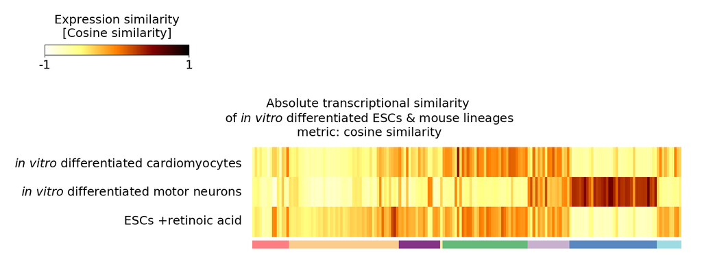

```
INFO-DPre target_similarity_heatmap:
Plot saved at C:\Users\LOaLoA\Anaconda3\Lib\DPre\examples\example3_ivd/abs_sim_hm.png
```

```python
import pandas as pd
from DPre import samples
import DPre

import DPre.main.config as conf
print(conf.HM_TOP)

# make a samples instance with the 3 samples above to produce one heatmap
all_expr = ivd_expr.loc[:, ['ivd cardiomyocytes', 'ivd motor neurons', 'ivd retinoic acid']]      # exclude controls
all_expr.columns = [it_in_vit+' differentiated cardiomyocytes',     # rename expression input for directly getting the correct names
                    it_in_vit+' differentiated motor neurons',
                    'ESCs +retinoic acid']
all_sample = samples(expression = all_expr,
                     name = it_in_vit + ' differentiated ESCs')
hm = t.target_similarity_heatmap(samples = all_sample,           # because no metric is passed, the default metric for target similarity is used: consine similarty
                                 differential = False,             # on command line this is passed by absolute = True, i.e. -a
                                 heatmap_height = 1.6,        # make heatmap higher
                                 heatmap_width = .13,
                                 hide_targetlabels = True,
                                 targetlabels_space = .45,
                                 samplelabels_space = 1.7,
                                 HM_TOP = 1,
                                 filename = 'abs_sim_hm.png',
                                 plt_show = True)
```

or on the command line we pass -a for absolute instead of differential=False:

```python
# copy and paste into your terminal
> python ../../dpre.py -pt "mouse" -se "ivd_expression.tsv" -ss "ivd cardiomyocytes"  -ss "ivd motor neurons"  -ss "ivd retinoic acid" -sn "in vitro differentiated ESCs" target_sim -a -hh 1.6 -hw .13 -hta -ta .45 -sa 1.7 -f "abs_sim_hm.png"
```